# LinearRegression slides

## Learning Objectives

We learn a whole lot today!

1. We learn about parametric models and we get to use one in practice
2. We learn about linear regression and how it fits into the ML picture

## Linear Regression

Linear regression is the most used model in practice, and it is our first parametric model, it has parameters which is calls weights and the algorithm associated with Linear regression concerns itself with finding what those weights will be.

In two dimensions Linear regression is easy to explain:

> Find the line of best fit through the X and y points.

Let's explore what using linear regression feels like:

```python
from sklearn.datasets import load_boston

boston_data = load_boston()

print(boston_data['DESCR'])
```

```
.. _boston_dataset:

Boston house prices dataset
---------------------------

**Data Set Characteristics:**

    :Number of Instances: 506

    :Number of Attributes: 13 numeric/categorical predictive. Median Value (attribute 14) is usually the target.

    :Attribute Information (in order):
        - CRIM     per capita crime rate by town
        - ZN       proportion of residential land zoned for lots over 25,000 sq.ft.
        - INDUS    proportion of non-retail business acres per town
        - CHAS     Charles River dummy variable (= 1 if tract bounds river; 0 otherwise)
        - NOX      nitric oxides concentration (parts per 10 million)
        - RM       average number of rooms per dwelling
        - AGE      proportion of owner-occupied units built prior to 1940
        - DIS      weighted distances to five Boston employment centres
        - RAD      index of accessibility to radial highways
        - TAX      full-value property-tax rate per $10,000
        - PTRATIO  pupil-teacher ratio by town
        - B        1000(Bk - 0.63)^2 where Bk is the proportion of blacks by town
        - LSTAT    % lower status of the population
        - MEDV     Median value of owner-occupied homes in $1000's

    :Missing Attribute Values: None

    :Creator: Harrison, D. and Rubinfeld, D.L.

This is a copy of UCI ML housing dataset.
https://archive.ics.uci.edu/ml/machine-learning-databases/housing/


This dataset was taken from the StatLib library which is maintained at Carnegie Mellon University.

The Boston house-price data of Harrison, D. and Rubinfeld, D.L. 'Hedonic
prices and the demand for clean air', J. Environ. Economics & Management,
vol.5, 81-102, 1978.   Used in Belsley, Kuh & Welsch, 'Regression diagnostics
...', Wiley, 1980.   N.B. Various transformations are used in the table on
pages 244-261 of the latter.

The Boston house-price data has been used in many machine learning papers that address regression
problems.

.. topic:: References

   - Belsley, Kuh & Welsch, 'Regression diagnostics: Identifying Influential Data and Sources of Collinearity', Wiley, 1980. 244-261.
   - Quinlan,R. (1993). Combining Instance-Based and Model-Based Learning. In Proceedings on the Tenth International Conference of Machine Learning, 236-243, University of Massachusetts, Amherst. Morgan Kaufmann.
```

```python
print (boston_data['data'].shape)
print (boston_data['target'].shape)
print (boston_data['feature_names'])
```

```
(506, 13)
(506,)
['CRIM' 'ZN' 'INDUS' 'CHAS' 'NOX' 'RM' 'AGE' 'DIS' 'RAD' 'TAX' 'PTRATIO'
 'B' 'LSTAT']
```

```python
from sklearn.model_selection import train_test_split

# we make our test set
X_train, X_test, y_train, y_test = train_test_split(boston_data['data'], boston_data['target'], test_size=0.2, random_state=1)

# and we make our validation set
X_train, X_val, y_train, y_val = train_test_split(X_train, y_train, test_size=0.2, random_state=1)
```

Training Dataset: The sample of data used to fit the model.

Validation Dataset: The sample of data used to provide an unbiased evaluation of a model fit on the training dataset while tuning model hyperparameters. Model doesn't learn from this.

Test Dataset: The sample of data used to provide an unbiased evaluation of a final model fit on the training dataset.

```python
print(X_train.shape, X_val.shape, X_test.shape)
```

```
(323, 13) (81, 13) (102, 13)
```

Let's visualize how using linear regression would work. Let's first look to see which features are the most correlated with the target:

```python
import pandas as pd
import numpy as np

full_data = np.append(X_train, y_train.reshape(-1, 1), axis=-1)

full_df = pd.DataFrame(data=full_data, columns=np.append(boston_data['feature_names'], 'target'))
```

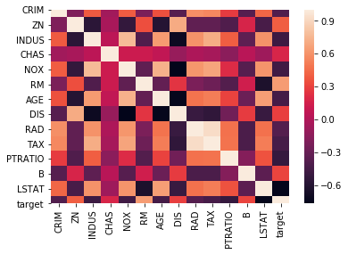

```python
%matplotlib inline
import seaborn as sns

g = sns.heatmap(full_df.corr())
g = g.set_xticklabels(g.get_xticklabels(), rotation=90)
```

We can see that some of the most correlated columns are: RM and LSTAT

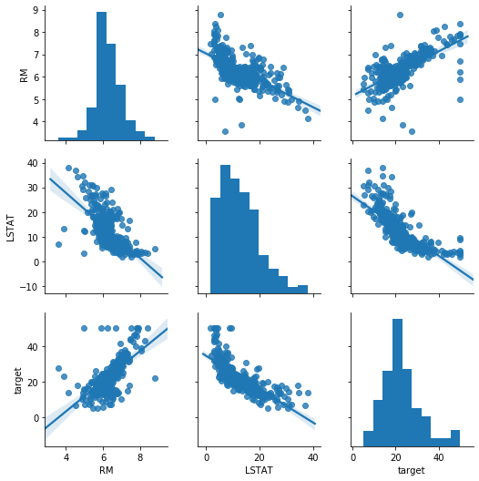

```python
sns.pairplot(full_df[['RM', 'LSTAT', 'target']], kind='reg')
```

Let's finish by doing the linear regression and then expaining its most common error measure:

```python
from sklearn.linear_model import LinearRegression

reg = LinearRegression(fit_intercept=True) ##fit_intercept=False sets the y-intercept to 0. If fit_intercept=True, the y-intercept will be determined by the line of best fit.
```

```python
reg.fit(X_train, y_train)
```

```
LinearRegression(copy_X=True, fit_intercept=True, n_jobs=None, normalize=False)
```

```python
# first we show the R^2
reg.score(X_val, y_val)
```

```
0.7261599367987428
```

```python
from sklearn.metrics import mean_absolute_error

# second we show the mean absolute error
mean_absolute_error(reg.predict(X_val), y_val)
```

```
3.5149975473966664
```

## How'd we do

We showed to measures: r-squared and MAE:

So in short, linear regression did not do too well. Perhaps one of the reasons is because of interactions in the data.

## Learning Objectives

We learn a whole lot today!

1. We learn about parametric models and we get to use one in practice
2. We learn about linear regression and how it fits into the ML picture